# How do changes in minimum wage affect unemployment?

### 2.2 Data Processing/Results

After loading the data for minimum wage and unemployment, we plot the data for some selected states as examples.

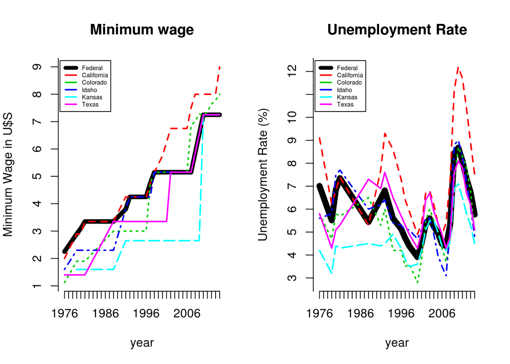

Conclusion: the minimum wage increases over time with some states having or lower rates than the federal minimum. The unemployment rate, on the other hand, fluctuates, probably in response to a number of variables, such as consumer sentiment, GDP, the state of global economy, etc.

Next I was interested in finding out whether there is a correlation between the minimum wage and unemployment at the federal level.

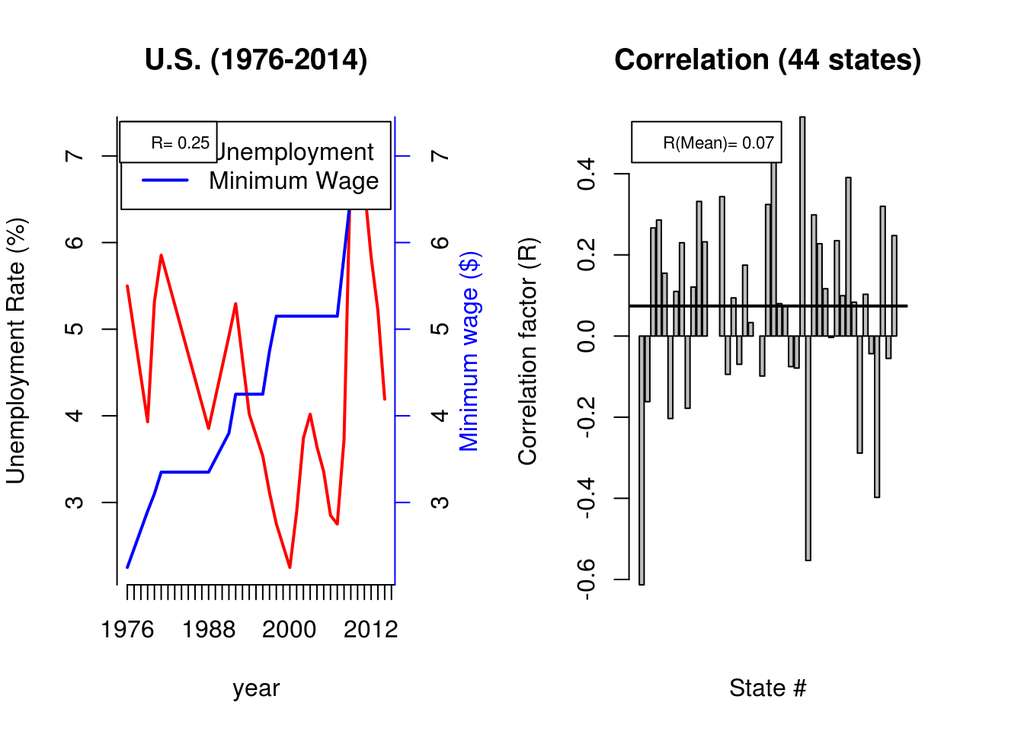

The correlation between the unemployment and minimum wage is 0.25 at the federal level but when we plot the correlation for every state individually, we don’t see a clear trend since the mean is slightly above 0. If there were a correlation, the value would be closer to 1.

# Analysis including GDP

## 3.1 Exploratory analysis

Since unemployment is strongly linked to the state of the economy, I decided to include GDP for this analysis. I loaded the data into a dataframe and selected the GDP values for the years in which unemployment data is available.

```r
# We read the real GDP (inflation corrected) in % betweem 1976-2015
gdp = read.csv("./data/gdp.csv", sep=",",head=TRUE)
rownames(gdp)<-as.numeric(gdp$year)
gdp[1]<-NULL
gdp<-gdp[years,]
```

## 3.2 Data Processing/Results

Below, I have plotted unemployment and GDP in the same graph.

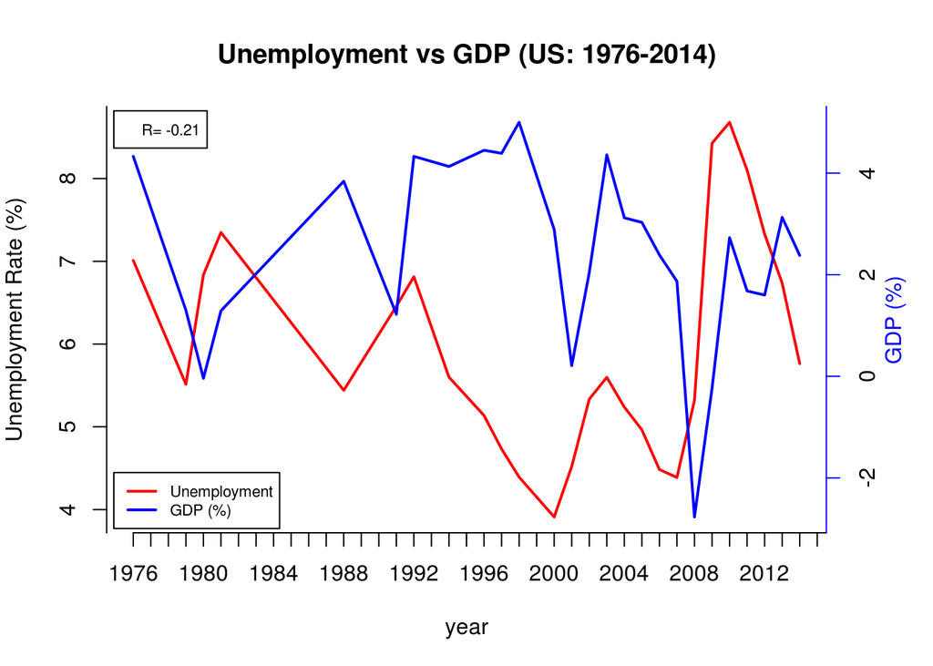

There is a negative correlation between GDP and unemployment, which is a well-studied phenomenon.

To see this effect more clearly, unemployment is plotted versus the inverse of GDP (1/gdp) and in order to prevent the division by zero, a constant GDP is added, which will not change the shape of this variable.

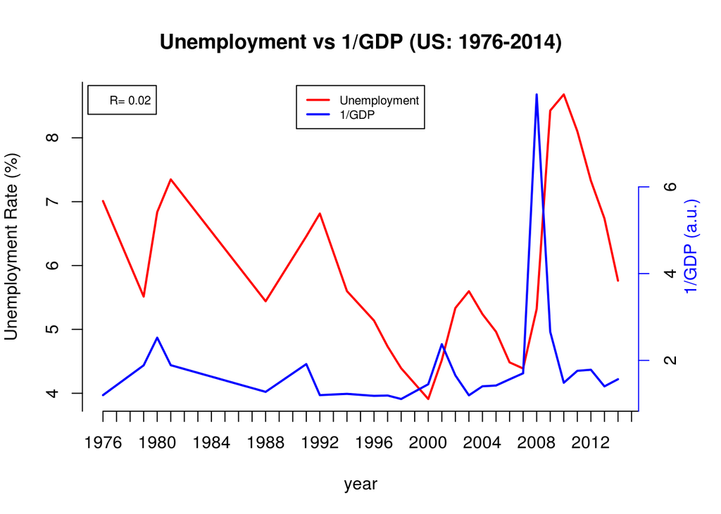

Here, we can see more a more clear correlation between these variables. It is noticeable that there is a time lag of 1-2 years in unemployment changes behind changes GDP. If we the 1/GDP curve is shifted by two years, we observe a significant increase in the correlation factor from 0.02 to 0.54.

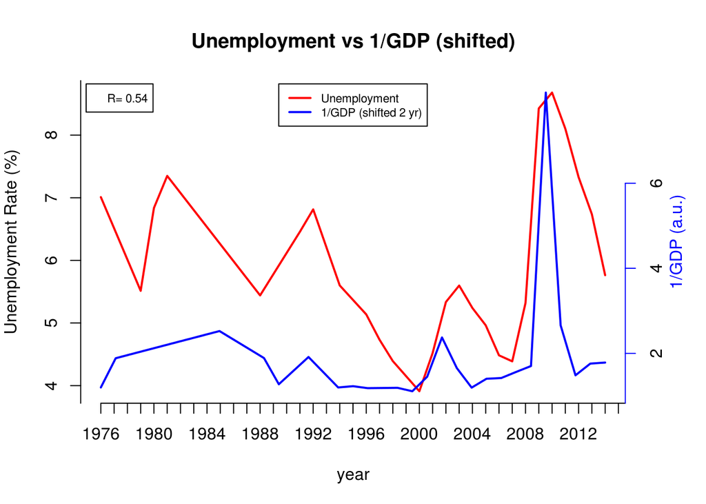

The unemployment data can then be normalized with the clear anticorrelation with GDP by dividing by the inverse of the GDP.

```r
unem_corrected<-unem[,3:26]
for(i in 1:nrow(unem)) {
  unem_corrected[i,]<-unem_corrected[i,]/y2[1:24]
}
```

The corrected federal and state unemployment and minimum wage are plotted and a histogram is generated with the correlation for 44 states.

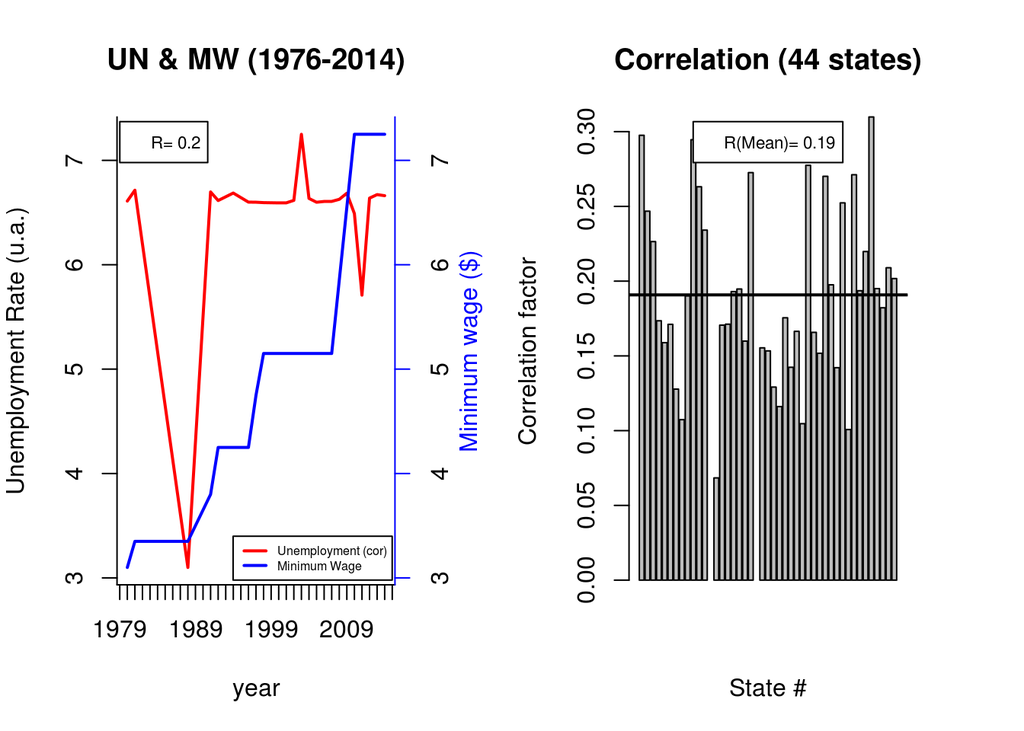

### 3. Conclusions

This analysis is a simplified study of the correlation between the minimum wage and the unemployment, using publicly available data. In this work we have included the GDP as correcting factor to account for economic factors that affect the unemployment. This work requires data with at least quarterly precision to obtain more precise correction factors, which would translate into more reliable outcomes.

### 4. References

1. http://www.economist.com/blogs/economist-explains/2014/01/economist-explains-11
2. http://www.slate.com/articles/news_and_politics/politics/2015/04/the_fight_for_15_it_s_a_bad_idea_raising_the_minimum_wage_to_15_would_hurt.html
3. http://www.huffingtonpost.com/bill-quigley/top-ten-arguments-for-rai_b_6879220.html
4. http://www.dol.gov/whd/state/stateMinWageHis.htm
5. http://www.bls.gov/lau/staadata.txt
6. http://www.multpl.com/us-real-gdp-growth-rate/table/by-year